# Analysis of Tamil psych verbs word order

Sadhana

2023-08-29

# Loading and updating the psych verbs dataset

#### 1. Loading the necessary libraries

```r
library(tidyverse)
library(broom)
library(Hmisc)
library(lme4)
library (vcd)
```

#### 2. Loading the annotation file into R

```r
tamil.psych.verb.df <- read.csv2(file.choose())
```

#### 3. Removing the unwanted columns

```r
tamil.psych.verb.df <- select(tamil.psych.verb.df, -c(Sentence, Case_of_subject_inTamil, Case_of_object_inTamil, Psych))
```

#### 4. Renaming the ‘EO…ES’ column

```r
tamil.psych.verb.df <- rename(tamil.psych.verb.df, EO_ES = EO...ES)
```

#### 5. Removing white spaces from the column values

```r
tamil.psych.verb.df <- mutate_if(tamil.psych.verb.df, is.character, str_trim)
```

#### 6. Updating the column values of ‘Case_of_object’ column

```r
tamil.psych.verb.df <- mutate(tamil.psych.verb.df, Case_of_object = replace(Case_of_object, Case_of_object == 'accusative (phrasal)','accusative'))

tamil.psych.verb.df <- mutate(tamil.psych.verb.df, Case_of_object = replace(Case_of_object, Case_of_object == 'dative (phrasal)','dative'))

tamil.psych.verb.df <- mutate(tamil.psych.verb.df, Case_of_object = replace(Case_of_object, Case_of_object %in% c( 'dative participle noun clause', 'accusative participle noun clause'),'participle noun clause'))

tamil.psych.verb.df <- mutate(tamil.psych.verb.df, Case_of_object = replace(Case_of_object, Case_of_object %in% c("special verbal participle 'aai'","special verbal participle 'endru'", "special verbal participle 'aaga'", "special verbal participle 'patri'","special verbal participle 'ena'", "special negative verbal participle 'indri'","special negative verbal participle 'illaamal'"),'special verbal participle'))

tamil.psych.verb.df <- mutate(tamil.psych.verb.df, Case_of_object = replace(Case_of_object, Case_of_object == 'negative verbal participle clause','verbal participle clause'))
```

```r
table (tamil.psych.verb.df$Case_of_object)
```

```
##
##                 accusative           adverbial clause
##                        296                         41
##           adverbial phrase                     dative
##                         32                         36
## infinite verbal participle     participle noun clause
##                        134                         73
##  special verbal participle   verbal participle clause
##                        247                        553
```

#### 7. Converting all the character columns as well as ID column into factors

```r
tamil.psych.verb.df <- tamil.psych.verb.df %>% mutate_if(is.character, as.factor) %>% mutate_at(c('ID'), as.factor)
```

#### 8. Converting integer column values into logarithmic values by adding new columns

```r
tamil.psych.verb.df <- mutate(tamil.psych.verb.df, log_syllable_subject = log(Syllable_of_subject), log_syllable_object = log(Syllable_of_object))
```

#### 9. Checking the structure of the dataframe

```r
str(tamil.psych.verb.df)
```

```
## 'data.frame':    1412 obs. of  17 variables:
##  $ ID                  : Factor w/ 1412 levels "1","2","3","4",..: 1 2 3 4 5 6 7 8 9 10 ...
##  $ Verb                : Factor w/ 10 levels "அஞ்சு (anju - to fear)",..: 8 8 8 8 8 8 8 8 8 8 ...
##  $ EO_ES               : Factor w/ 2 levels "EO","ES": 2 2 2 2 2 2 2 2 2 2 ...
##  $ Word_order          : Factor w/ 2 levels "OSV","SOV": 2 1 2 2 1 2 1 1 1 1 ...
##  $ Phrasal_subject     : Factor w/ 2 levels "no","yes": 1 1 2 1 1 2 1 1 1 1 ...
##  $ Clausal_object      : Factor w/ 2 levels "no","yes": 2 2 2 2 2 2 2 2 2 2 ...
##  $ Case_of_subject     : Factor w/ 2 levels "nominative","nominative (phrasal)": 1 1 2 1 1 2 1 1 1 1 ...
##  $ Case_of_object      : Factor w/ 8 levels "accusative","adverbial clause",..: 8 7 8 8 7 8 7 8 7 7 ...
##  $ Animacy_of_subject  : Factor w/ 3 levels "animate","inanimate",..: 3 3 3 3 3 3 3 3 3 3 ...
##  $ Animacy_of_object   : Factor w/ 4 levels "animate","inanimate",..: 3 3 3 3 3 3 3 3 3 3 ...
##  $ Pronoun_subject     : Factor w/ 2 levels "no","yes": 1 2 1 1 2 1 2 1 1 1 ...
##  $ Pronoun_object      : Factor w/ 2 levels "no","yes": 1 1 1 1 1 1 1 1 1 1 ...
##  $ Syllable_of_subject : int  1 1 6 1 1 5 1 1 1 1 ...
##  $ Syllable_of_object  : int  3 10 5 4 10 6 7 4 5 7 ...
##  $ Focus               : Factor w/ 6 levels "none","object (emphasized)",..: 1 1 1 1 1 1 2 3 3 1 ...
##  $ log_syllable_subject: num  0 0 1.79 0 0 ...
##  $ log_syllable_object : num  1.1 2.3 1.61 1.39 2.3 ...
```

```r
summary (tamil.psych.verb.df)
```

```
##        ID                                  Verb     EO_ES     Word_order
##  1      :   1   வெறு (veru - to hate)        :198   EO:  93   OSV:551
##  2      :   1   அஞ்சு (anju - to fear)        :197   ES:1319   SOV:861
##  3      :   1   வருந்து (varundhu - to be sad):196
##  4      :   1   தவி (thavi - to suffer)      :193
##  5      :   1   விரும்பு (virumbu - to like)  :176
##  6      :   1   மகிழ் (magizh - to be happy)  :174
##  (Other):1406   (Other)                      :278
##  Phrasal_subject Clausal_object             Case_of_subject
##  no :788         no : 364       nominative          :786
##  yes:624         yes:1048       nominative (phrasal):626
##
##
##
##
##
##                     Case_of_object Animacy_of_subject Animacy_of_object
##  verbal participle clause  :553    animate  :  16     animate  :   3
##  accusative                :296    inanimate:  57     inanimate: 132
##  special verbal participle :247    rational :1339     none     :1080
##  infinite verbal participle:134                       rational : 197
##  participle noun clause    : 73
##  adverbial clause          : 41
##  (Other)                   : 68
##  Pronoun_subject Pronoun_object Syllable_of_subject Syllable_of_object
##  no :1095        no :1314       Min.   : 1.000      Min.   : 1.000
##  yes: 317        yes:  98       1st Qu.: 1.000      1st Qu.: 2.000
##                                 Median : 1.000      Median : 4.000
##                                 Mean   : 2.621      Mean   : 5.365
##                                 3rd Qu.: 3.000      3rd Qu.: 7.000
##                                 Max.   :20.000      Max.   :26.000
##
##                                        Focus     log_syllable_subject
##  none                                     :798   Min.   :0.0000
##  object (emphasized)                      :123   1st Qu.:0.0000
##  subject                                  :389   Median :0.0000
##  subject (emphasized)                     : 92   Mean   :0.6332
##  subject (emphasized), object (emphasized):  6   3rd Qu.:1.0986
##  verb (emphasized)                        :  4   Max.   :2.9957
##
##  log_syllable_object
##  Min.   :0.0000
##  1st Qu.:0.6931
##  Median :1.3863
##  Mean   :1.4005
##  3rd Qu.:1.9459
##  Max.   :3.2581
##
```

#### 10. Checking the overall count of SOV and OSV word order

```r
table (tamil.psych.verb.df$Word_order)
```

```
##
## OSV SOV
## 551 861
```

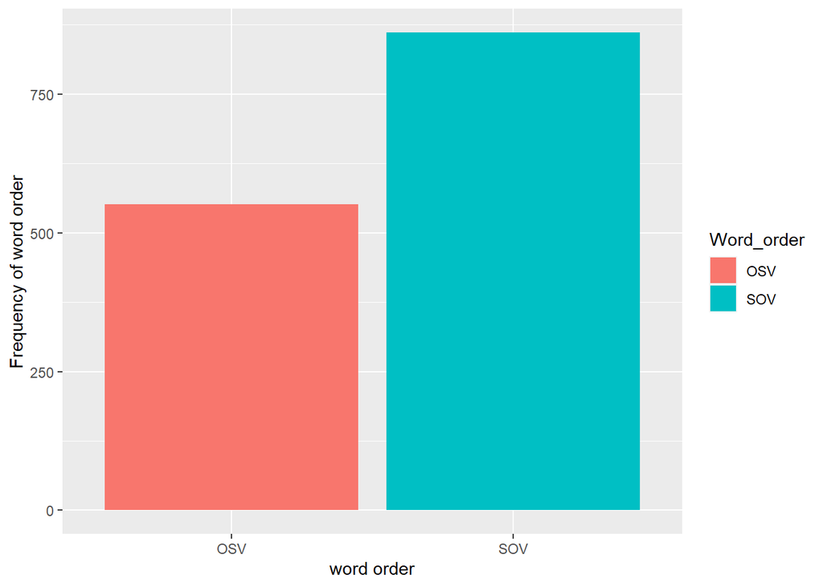

```r
ggplot(tamil.psych.verb.df, aes(x = Word_order)) +
  geom_bar(stat = "count", aes(fill = Word_order)) +
  labs(x = "word order", y = "Frequency of word order")
```

#### 11. Checking the count of word order against all the categorical variables

```r
lapply(tamil.psych.verb.df[, c(2:3, 5:12, 15)],function(c){table(tamil.psych.verb.df$Word_order,c)})
```

```
## $Verb
##      c
##       அஞ்சு (anju - to fear) களி (kali - to ecstasize) தவி (thavi - to suffer)
##   OSV                   101                         0                      50
##   SOV                    96                        40                     143
##      c
##       திகை (thigai - to shock) நெகிழ் (negizh - to delight)
##   OSV                       31                          13
##   SOV                       49                          17
##      c
##       மகிழ் (magizh - to be happy) வருந்து (varundhu - to be sad)
##   OSV                          32                            86
##   SOV                         142                           110
##      c
##       விய (viya - to wonder) விரும்பு (virumbu - to like) வெறு (veru - to hate)
##   OSV                     69                          87                    82
##   SOV                     59                          89                   116
##
## $EO_ES
##      c
##        EO  ES
##   OSV   8 543
##   SOV  85 776
##
## $Phrasal_subject
##      c
##        no yes
##   OSV 456  95
##   SOV 332 529
##
## $Clausal_object
##      c
##        no yes
##   OSV 105 446
##   SOV 259 602
##
## $Case_of_subject
##      c
##       nominative nominative (phrasal)
##   OSV        456                   95
```

[output cut: 34 more lines]

```
## $Pronoun_object
##      c
##        no yes
##   OSV 535  16
##   SOV 779  82
##
## $Focus
##      c
##       none object (emphasized) subject subject (emphasized)
##   OSV   73                  67     386                   24
##   SOV  725                  56       3                   68
##      c
##       subject (emphasized), object (emphasized) verb (emphasized)
##   OSV                                         1                 0
##   SOV                                         5                 4
```

#### 12. Checking the word order against the numerical variables i.e., syllabe of subject and object

```r
tamil.psych.verb.df %>% group_by(Word_order) %>% summarise(across(c(Syllable_of_subject, Syllable_of_object), mean))
```

```
## # A tibble: 2 × 3
##   Word_order Syllable_of_subject Syllable_of_object
##   <fct>                    <dbl>              <dbl>
## 1 OSV                       1.38               7.12
## 2 SOV                       3.42               4.24
```

#### 13. Displaying the count of word order against cases of object in bar chart

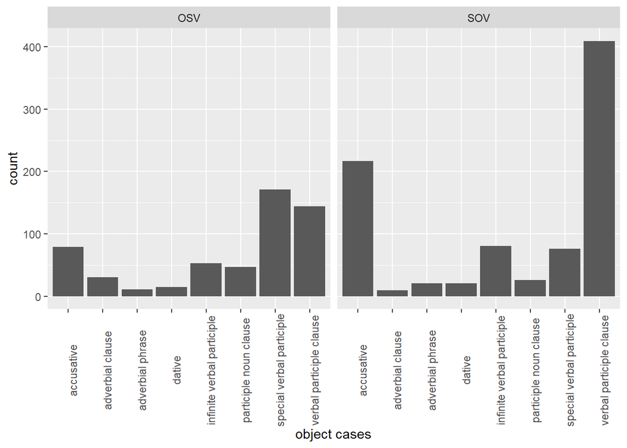

```r
ggplot(tamil.psych.verb.df, aes(x = Case_of_object)) +
       geom_bar(stat = "count") +
   facet_wrap(~Word_order) +
  labs(x = "object cases", y = "count") +
    theme(axis.text.x = element_text(angle = 90))
```

#### 14. Displaying the count of word order against the focus in bar chart

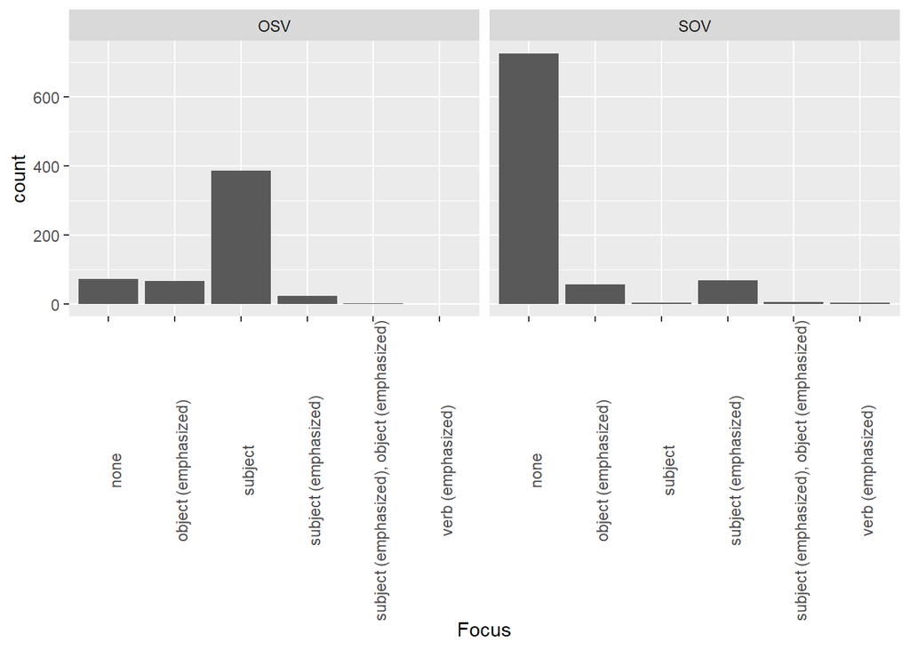

```r
ggplot(tamil.psych.verb.df, aes(x = Focus)) +
       geom_bar(stat = "count") +
   facet_wrap(~Word_order) +
  labs(x = "Focus", y = "count") +
    theme(axis.text.x = element_text(angle = 90))
```

#### 15. Changing the reference levels

```r
tamil.psych.verb.df <- mutate(tamil.psych.verb.df, EO_ES= relevel(EO_ES, ref= 'ES'))
levels (tamil.psych.verb.df$EO_ES)
```

```
## [1] "ES" "EO"
```

```r
tamil.psych.verb.df <- mutate(tamil.psych.verb.df,
                              Case_of_object = relevel(Case_of_object, ref= 'verbal participle clause'))
levels (tamil.psych.verb.df$Case_of_object)
```

```
## [1] "verbal participle clause"   "accusative"
## [3] "adverbial clause"           "adverbial phrase"
## [5] "dative"                     "infinite verbal participle"
## [7] "participle noun clause"     "special verbal participle"
```

```r
tamil.psych.verb.df <- mutate(tamil.psych.verb.df, Focus = relevel(Focus, ref= 'object (emphasized)'))
levels (tamil.psych.verb.df$Focus)
```

```
## [1] "object (emphasized)"
## [2] "none"
## [3] "subject"
## [4] "subject (emphasized)"
## [5] "subject (emphasized), object (emphasized)"
## [6] "verb (emphasized)"
```

# Model 1: Generalized Linear Model (GLM)

### Creating model 1

```r
tamil.psych.verb.glm <- glm(Word_order ~ EO_ES + Case_of_subject + Case_of_object + Animacy_of_subject + Animacy_of_object + Pronoun_subject + Pronoun_object + log_syllable_subject + log_syllable_object + Focus, family ="binomial", data = tamil.psych.verb.df)

tamil.psych.verb.glm1 <- glm(Word_order ~ EO_ES + Case_of_subject + Case_of_object + log_syllable_subject + log_syllable_object + Focus, family ="binomial", data = tamil.psych.verb.df)
```

```r
anova(tamil.psych.verb.glm1, tamil.psych.verb.glm, test = "Chisq")
```

```
## Analysis of Deviance Table
##
## Model 1: Word_order ~ EO_ES + Case_of_subject + Case_of_object + log_syllable_subject +
##     log_syllable_object + Focus
## Model 2: Word_order ~ EO_ES + Case_of_subject + Case_of_object + Animacy_of_subject +
##     Animacy_of_object + Pronoun_subject + Pronoun_object + log_syllable_subject +
##     log_syllable_object + Focus
##   Resid. Df Resid. Dev Df Deviance Pr(>Chi)
## 1      1395     476.69
## 2      1388     467.32  7   9.3678   0.2273
```

```r
summary(tamil.psych.verb.glm1)
```

```
##
## Call:
## glm(formula = Word_order ~ EO_ES + Case_of_subject + Case_of_object +
##     log_syllable_subject + log_syllable_object + Focus, family = "binomial",
##     data = tamil.psych.verb.df)
##
## Coefficients:
##                                                 Estimate Std. Error z value
## (Intercept)                                      4.23399    0.56008   7.560
## EO_ESEO                                         -0.03413    0.93518  -0.036
## Case_of_subjectnominative (phrasal)              0.28168    0.45035   0.625
## Case_of_objectaccusative                        -1.37038    0.46864  -2.924
## Case_of_objectadverbial clause                  -1.59350    0.69254  -2.301
## Case_of_objectadverbial phrase                  -0.56394    1.16627  -0.484
## Case_of_objectdative                            -2.36454    0.98054  -2.411
## Case_of_objectinfinite verbal participle        -0.28451    0.45625  -0.624
## Case_of_objectparticiple noun clause            -1.04138    0.60311  -1.727
## Case_of_objectspecial verbal participle         -2.34947    0.32444  -7.242
## log_syllable_subject                             1.18945    0.35189   3.380
## log_syllable_object                             -1.95472    0.22261  -8.781
## Focusnone                                        1.73825    0.31058   5.597
## Focussubject                                    -6.59887    0.71319  -9.253
## Focussubject (emphasized)                       -0.33159    0.41723  -0.795
## Focussubject (emphasized), object (emphasized)  -0.10056    1.21775  -0.083
## Focusverb (emphasized)                          15.55202  616.13615   0.025
##                                                Pr(>|z|)
## (Intercept)                                    4.04e-14 ***
## EO_ESEO                                        0.970890
## Case_of_subjectnominative (phrasal)            0.531669
## Case_of_objectaccusative                       0.003454 **
## Case_of_objectadverbial clause                 0.021395 *
## Case_of_objectadverbial phrase                 0.628712
## Case_of_objectdative                           0.015888 *
## Case_of_objectinfinite verbal participle       0.532908
## Case_of_objectparticiple noun clause           0.084224 .
## Case_of_objectspecial verbal participle        4.43e-13 ***
## log_syllable_subject                           0.000724 ***
## log_syllable_object                             < 2e-16 ***
## Focusnone                                      2.18e-08 ***
## Focussubject                                    < 2e-16 ***
## Focussubject (emphasized)                      0.426775
## Focussubject (emphasized), object (emphasized) 0.934185
## Focusverb (emphasized)                         0.979863
## ---
## Signif. codes:  0 '***' 0.001 '**' 0.01 '*' 0.05 '.' 0.1 ' ' 1
##
## (Dispersion parameter for binomial family taken to be 1)
##
##     Null deviance: 1888.83  on 1411  degrees of freedom
## Residual deviance:  476.69  on 1395  degrees of freedom
## AIC: 510.69
##
## Number of Fisher Scoring iterations: 14
```

Calculating the probabilities for SOV.

```r
intercept <- tidy(tamil.psych.verb.glm1)$estimate[1]
print ("Probability of SOV order with reference levels")
```

```
## [1] "Probability of SOV order with reference levels"
```

```r
plogis(intercept)
```

```
## [1] 0.9857126
```

Calculating the probabilities for OSV.

```r
print ("Probability of OSV order with reference levels")
```

```
## [1] "Probability of OSV order with reference levels"
```

```r
1-plogis(intercept)
```

```
## [1] 0.0142874
```

### Plotting the predictions of model 1 using ggplot

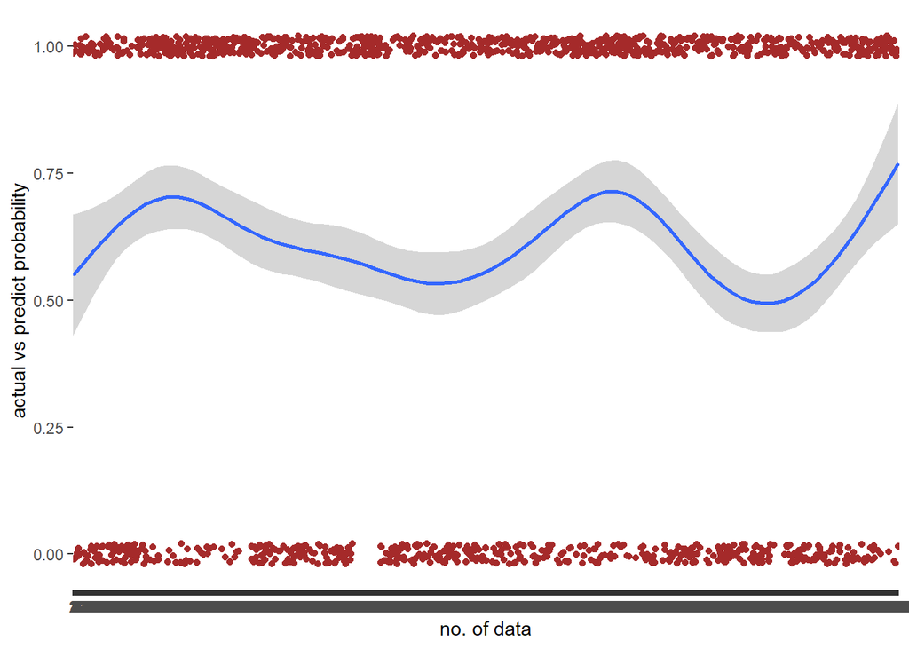

```r
tamil.psych.verb.df <- mutate(tamil.psych.verb.df, Word_order1 = ifelse(Word_order =='SOV', 1, 0))

tamil.psych.verb.df$pred_model1 <- predict(tamil.psych.verb.glm1, type = "response")


ggplot(tamil.psych.verb.df, aes(x = ID, y = Word_order1, group = 1)) +
  geom_jitter(width = 1, height = 0.02, color = "brown", show.legend = FALSE) +
  geom_smooth(aes(y = pred_model1)) +
  labs(x = "no. of data", y = "actual vs predict probability")
```

### Evaluation of model 1

```r
options(scipen = 999)
somers2(tamil.psych.verb.df$pred_model1, tamil.psych.verb.df$Word_order1)
```

```
##            C          Dxy            n      Missing
##    0.9821705    0.9643410 1412.0000000    0.0000000
```

# Model 2: Generalized Linear Mixed Model (GLMM)

#### Checking data count for each verb against the word order

```r
tamil.psych.verb.df %>% group_by(Verb ,Word_order) %>% summarise(Count = n()) %>% arrange(desc(Count))
```

```
## # A tibble: 19 × 3
## # Groups:   Verb [10]
##    Verb                          Word_order Count
##    <fct>                         <fct>      <int>
##  1 தவி (thavi - to suffer)       SOV          143
##  2 மகிழ் (magizh - to be happy)   SOV          142
##  3 வெறு (veru - to hate)         SOV          116
##  4 வருந்து (varundhu - to be sad) SOV          110
##  5 அஞ்சு (anju - to fear)         OSV          101
##  6 அஞ்சு (anju - to fear)         SOV           96
##  7 விரும்பு (virumbu - to like)   SOV           89
##  8 விரும்பு (virumbu - to like)   OSV           87
##  9 வருந்து (varundhu - to be sad) OSV           86
## 10 வெறு (veru - to hate)         OSV           82
## 11 விய (viya - to wonder)        OSV           69
## 12 விய (viya - to wonder)        SOV           59
## 13 தவி (thavi - to suffer)       OSV           50
## 14 திகை (thigai - to shock)      SOV           49
## 15 களி (kali - to ecstasize)     SOV           40
## 16 மகிழ் (magizh - to be happy)   OSV           32
## 17 திகை (thigai - to shock)      OSV           31
## 18 நெகிழ் (negizh - to delight)   SOV           17
## 19 நெகிழ் (negizh - to delight)   OSV           13
```